# Severe weather event and economic consequences

Andyintae

2020 8 1

## Synopsis

Storms and other severe weather events can cause both public health and economic problems for communities and municipalities. Many severe events can result in fatalities, injuries, and property damage, and preventing such outcomes to the extent possible is a key concern. This analysis involves exploring the U.S. National Oceanic and Atmospheric Administration’s (NOAA) storm database. This database tracks characteristics of major storms and weather events in the United States, including when and where they occur, as well as estimates of any fatalities, injuries, and property damage.  
The events in the database start in the year 1950 and end in November 2011. In the earlier years of the database there are generally fewer events recorded, most likely due to a lack of good records. More recent years should be considered more complete.  
I am going to analyze the storm data set to figure out, which types of events are most harmful with respect to population health. And I will also analyze, which types of events have the greatest economic consequences.  
This analysis will be conducted using reproducible method so that anyone can confirm them. You can find how to processing data and the result of it. Let’s review the relationship between severe weather event and economic consequences.

*Excerpted from project introduction https://www.coursera.org/learn/reproducible-research/peer/OMZ37/course-project-2*

## Package Loading

```r
library(readr)
library(dplyr)
```

```r
library(ggplot2)
library(tidyr)
library(forcats)
```

## Data Processing

### 1. First of all, we should download the data and load it.

```r
wd <- getwd()

url_storm <- "https://d396qusza40orc.cloudfront.net/repdata%2Fdata%2FStormData.csv.bz2"

download.file(url_storm, destfile = paste0(wd, "/StormData.csv.bz2"))

stormdata <- read_csv("StormData.csv.bz2",
                      col_types = list(PROPDMGEXP = col_character(), CROPDMGEXP = col_character()))
```

### 2. Let’s check the data is loaded well and have a glimpse it.

```r
head(stormdata)
```

```
## # A tibble: 6 x 37
##   STATE__ BGN_DATE BGN_TIME TIME_ZONE COUNTY COUNTYNAME STATE EVTYPE BGN_RANGE
##     <dbl> <chr>    <chr>    <chr>      <dbl> <chr>      <chr> <chr>      <dbl>
## 1       1 4/18/19~ 0130     CST           97 MOBILE     AL    TORNA~         0
## 2       1 4/18/19~ 0145     CST            3 BALDWIN    AL    TORNA~         0
## 3       1 2/20/19~ 1600     CST           57 FAYETTE    AL    TORNA~         0
## 4       1 6/8/195~ 0900     CST           89 MADISON    AL    TORNA~         0
## 5       1 11/15/1~ 1500     CST           43 CULLMAN    AL    TORNA~         0
## 6       1 11/15/1~ 2000     CST           77 LAUDERDALE AL    TORNA~         0
## # ... with 28 more variables: BGN_AZI <lgl>, BGN_LOCATI <lgl>, END_DATE <lgl>,
## #   END_TIME <lgl>, COUNTY_END <dbl>, COUNTYENDN <lgl>, END_RANGE <dbl>,
## #   END_AZI <lgl>, END_LOCATI <lgl>, LENGTH <dbl>, WIDTH <dbl>, F <dbl>,
## #   MAG <dbl>, FATALITIES <dbl>, INJURIES <dbl>, PROPDMG <dbl>,
## #   PROPDMGEXP <chr>, CROPDMG <dbl>, CROPDMGEXP <chr>, WFO <lgl>,
## #   STATEOFFIC <lgl>, ZONENAMES <lgl>, LATITUDE <dbl>, LONGITUDE <dbl>,
## #   LATITUDE_E <dbl>, LONGITUDE_ <dbl>, REMARKS <lgl>, REFNUM <dbl>
```

```r
tail(stormdata)
```

```
## # A tibble: 6 x 37
##   STATE__ BGN_DATE BGN_TIME TIME_ZONE COUNTY COUNTYNAME STATE EVTYPE BGN_RANGE
##     <dbl> <chr>    <chr>    <chr>      <dbl> <chr>      <chr> <chr>      <dbl>
## 1      47 11/28/2~ 03:00:0~ CST           21 TNZ001>00~ TN    WINTE~         0
## 2      56 11/30/2~ 10:30:0~ MST            7 WYZ007 - ~ WY    HIGH ~         0
## 3      30 11/10/2~ 02:48:0~ MST            9 MTZ009 - ~ MT    HIGH ~         0
## 4       2 11/8/20~ 02:58:0~ AKS          213 AKZ213     AK    HIGH ~         0
## 5       2 11/9/20~ 10:21:0~ AKS          202 AKZ202     AK    BLIZZ~         0
## 6       1 11/28/2~ 08:00:0~ CST            6 ALZ006     AL    HEAVY~         0
## # ... with 28 more variables: BGN_AZI <lgl>, BGN_LOCATI <lgl>, END_DATE <lgl>,
## #   END_TIME <lgl>, COUNTY_END <dbl>, COUNTYENDN <lgl>, END_RANGE <dbl>,
## #   END_AZI <lgl>, END_LOCATI <lgl>, LENGTH <dbl>, WIDTH <dbl>, F <dbl>,
## #   MAG <dbl>, FATALITIES <dbl>, INJURIES <dbl>, PROPDMG <dbl>,
## #   PROPDMGEXP <chr>, CROPDMG <dbl>, CROPDMGEXP <chr>, WFO <lgl>,
## #   STATEOFFIC <lgl>, ZONENAMES <lgl>, LATITUDE <dbl>, LONGITUDE <dbl>,
## #   LATITUDE_E <dbl>, LONGITUDE_ <dbl>, REMARKS <lgl>, REFNUM <dbl>
```

```r
glimpse(stormdata)
```

```
## Rows: 902,297
## Columns: 37
## $ STATE__    <dbl> 1, 1, 1, 1, 1, 1, 1, 1, 1, 1, 1, 1, 1, 1, 1, 1, 1, 1, 1,...
## $ BGN_DATE   <chr> "4/18/1950 0:00:00", "4/18/1950 0:00:00", "2/20/1951 0:0...
## $ BGN_TIME   <chr> "0130", "0145", "1600", "0900", "1500", "2000", "0100", ...
## $ TIME_ZONE  <chr> "CST", "CST", "CST", "CST", "CST", "CST", "CST", "CST", ...
## $ COUNTY     <dbl> 97, 3, 57, 89, 43, 77, 9, 123, 125, 57, 43, 9, 73, 49, 1...
## $ COUNTYNAME <chr> "MOBILE", "BALDWIN", "FAYETTE", "MADISON", "CULLMAN", "L...
## $ STATE      <chr> "AL", "AL", "AL", "AL", "AL", "AL", "AL", "AL", "AL", "A...
## $ EVTYPE     <chr> "TORNADO", "TORNADO", "TORNADO", "TORNADO", "TORNADO", "...
## $ BGN_RANGE  <dbl> 0, 0, 0, 0, 0, 0, 0, 0, 0, 0, 0, 0, 0, 0, 0, 0, 0, 0, 0,...
## $ BGN_AZI    <lgl> NA, NA, NA, NA, NA, NA, NA, NA, NA, NA, NA, NA, NA, NA, ...
## $ BGN_LOCATI <lgl> NA, NA, NA, NA, NA, NA, NA, NA, NA, NA, NA, NA, NA, NA, ...
## $ END_DATE   <lgl> NA, NA, NA, NA, NA, NA, NA, NA, NA, NA, NA, NA, NA, NA, ...
## $ END_TIME   <lgl> NA, NA, NA, NA, NA, NA, NA, NA, NA, NA, NA, NA, NA, NA, ...
```

[output cut: 24 more lines]

### 3. Select columns and transform the unit.

“H” and “h” mean “hecto” which is 100 = 10^2.  
“K” and “k” mean “Kilo” which is 1,000 = 10^3.  
“M” and “m” mean “Million” which is 1,000,000 = 10^6.  
“B” and “b” mean “Billion” which is 1,000,000,000 = 10^9.

```r
stormdata_evtype <- stormdata %>%
    select(EVTYPE, FATALITIES, INJURIES, PROPDMG, PROPDMGEXP, CROPDMG, CROPDMGEXP) %>%
    mutate(PROPDMGEXP_scale = if_else(is.na(PROPDMGEXP), 1,
                              if_else(PROPDMGEXP == "K", 10^3,
                              if_else(PROPDMGEXP %in% c("m", "M"), 10^6,
                              if_else(PROPDMGEXP == "B", 10^9,
                              if_else(PROPDMGEXP == "1", 10^1,
                              if_else(PROPDMGEXP %in% c("2","H","h"), 10^2,
                              if_else(PROPDMGEXP == "3", 10^3,
                              if_else(PROPDMGEXP == "4", 10^4,
                              if_else(PROPDMGEXP == "5", 10^5,
                              if_else(PROPDMGEXP == "6", 10^6,
                              if_else(PROPDMGEXP == "7", 10^7,
                              if_else(PROPDMGEXP == "8", 10^8,
                              if_else(PROPDMGEXP == "9", 10^9, 1))))))))))))),
           CROPDMGEXP_scale = if_else(is.na(CROPDMGEXP), 1,
                              if_else(CROPDMGEXP %in% c("K", "k"), 10^3,
                              if_else(CROPDMGEXP %in% c("m", "M"), 10^6,
                              if_else(CROPDMGEXP == "B", 10^9,
                              if_else(CROPDMGEXP == "2", 10^2, 1))))))
```

## Result

### Q1. Across the United States, which types of events are most harmful with respect to population health?

**Answer : TORNADO (Fatalities : 5,633 / Injuries : 91,346 / Total_CASUALTIES : 96,979)**

**Table.1 : Weather event and population health**

```r
stormdata_evtype %>%
    group_by(EVTYPE) %>%
    summarise(SUM_FATALITIES = sum(FATALITIES),
              SUM_INJURIES   = sum(INJURIES),
              Total_CASUALTIES = SUM_FATALITIES + SUM_INJURIES) %>%
    arrange(desc(Total_CASUALTIES))
```

```
## # A tibble: 977 x 4
##    EVTYPE            SUM_FATALITIES SUM_INJURIES Total_CASUALTIES
##    <chr>                      <dbl>        <dbl>            <dbl>
##  1 TORNADO                     5633        91346            96979
##  2 EXCESSIVE HEAT              1903         6525             8428
##  3 TSTM WIND                    504         6957             7461
##  4 FLOOD                        470         6789             7259
##  5 LIGHTNING                    816         5230             6046
##  6 HEAT                         937         2100             3037
##  7 FLASH FLOOD                  978         1777             2755
##  8 ICE STORM                     89         1975             2064
##  9 THUNDERSTORM WIND            133         1488             1621
## 10 WINTER STORM                 206         1321             1527
## # ... with 967 more rows
```

**Plot.1 : Weather event and population health**

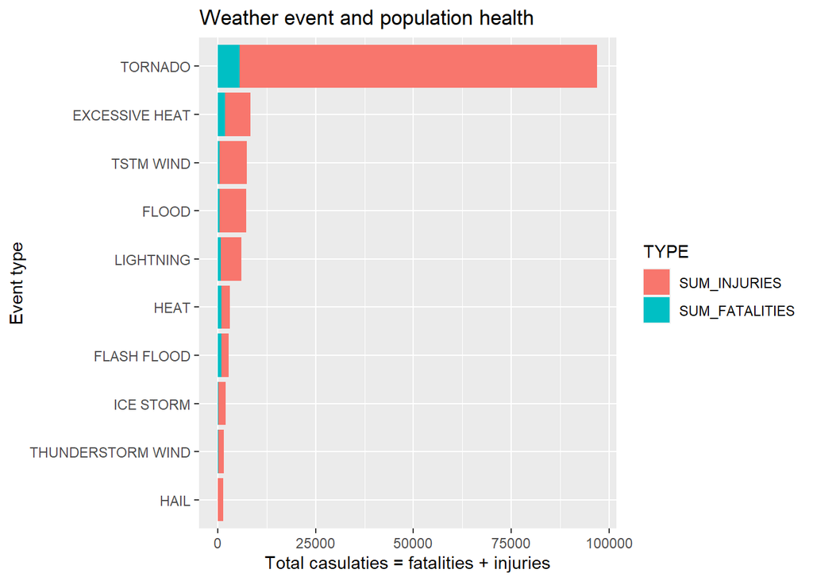

```r
stormdata_evtype %>%
  group_by(EVTYPE) %>%
  summarise(SUM_FATALITIES = sum(FATALITIES),
            SUM_INJURIES   = sum(INJURIES)) %>%
  top_n(10) %>%
  gather(TYPE, Total_CASUALTIES, -EVTYPE) %>%
  mutate(EVTYPE = fct_reorder(as.factor(EVTYPE),Total_CASUALTIES),
         TYPE = factor(TYPE, levels = c("SUM_INJURIES", "SUM_FATALITIES"))) %>%
  group_by(EVTYPE) %>%
  ggplot(aes(x = EVTYPE, y = Total_CASUALTIES, fill = TYPE))+
  geom_col() +
  labs(x = "Event type", y = "Total casulaties = fatalities + injuries",
       title = "Weather event and population health") +
  coord_flip()
```

### Q2. Across the United States, which types of events have the greatest economic consequences?

**Table.2 : Weather event and Economic consequences**

```r
stormdata_evtype %>%
  mutate(PROPDMG_final = PROPDMG * PROPDMGEXP_scale,
         CROPDMG_final = CROPDMG * CROPDMGEXP_scale) %>%
  group_by(EVTYPE) %>%
  summarise(SUM_PROPDMG = sum(PROPDMG_final, na.rm = TRUE),
            SUM_CROPDMG = sum(CROPDMG_final, na.rm = TRUE),
            Total_DMG   = SUM_PROPDMG + SUM_CROPDMG) %>%
  arrange(desc(Total_DMG))
```

```
## # A tibble: 977 x 4
##    EVTYPE              SUM_PROPDMG SUM_CROPDMG     Total_DMG
##    <chr>                     <dbl>       <dbl>         <dbl>
##  1 FLOOD             144657709807   5661968450 150319678257
##  2 HURRICANE/TYPHOON  69305840000   2607872800  71913712800
##  3 TORNADO            56947380676.   414953270  57362333946.
##  4 STORM SURGE        43323536000         5000  43323541000
##  5 HAIL               15735267513.  3025954473  18761221986.
##  6 FLASH FLOOD        16822723978.  1421317100  18244041078.
##  7 DROUGHT             1046106000  13972566000  15018672000
##  8 HURRICANE          11868319010   2741910000  14610229010
##  9 RIVER FLOOD         5118945500   5029459000  10148404500
## 10 ICE STORM           3944927860   5022113500   8967041360
## # ... with 967 more rows
```

**Plot.2 : Weather event and Economic consequences**

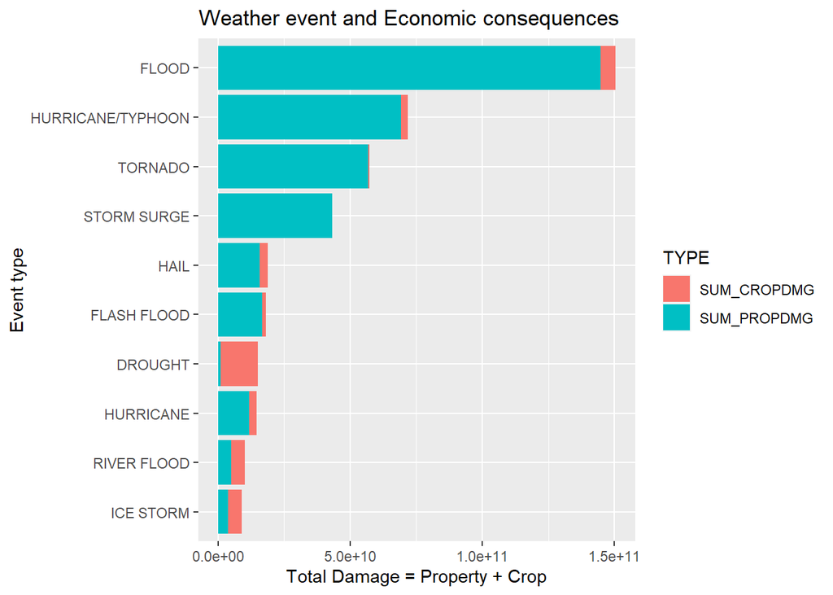

```r
stormdata_evtype %>%
  mutate(PROPDMG_final = PROPDMG * PROPDMGEXP_scale,
         CROPDMG_final = CROPDMG * CROPDMGEXP_scale) %>%
  group_by(EVTYPE) %>%
  summarise(SUM_PROPDMG = sum(PROPDMG_final, na.rm = TRUE),
            SUM_CROPDMG = sum(CROPDMG_final, na.rm = TRUE),
            Total_DMG   = SUM_PROPDMG + SUM_CROPDMG) %>%
  arrange(desc(Total_DMG)) %>%
  top_n(10) %>%
  gather(TYPE, Total_DMG, -EVTYPE, -Total_DMG) %>%
  mutate(EVTYPE = fct_reorder(as.factor(EVTYPE),Total_DMG)) %>%
  group_by(EVTYPE) %>%
  ggplot(aes(x = EVTYPE, y = Total_DMG, fill = TYPE))+
  geom_col() +
  labs(x = "Event type", y = "Total Damage = Property + Crop",
       title = "Weather event and Economic consequences") +
  coord_flip()
```

**End of analysis.**